# DS 220 Project 2: Biopics Data Analysis and Visualization

### Abigail Weinstein

This Jupyter notebook is designed to clean, analyze, visualize, and discuss the Biopics dataset from FiveThirtyEight. First, the Numerous queries needed for analysis will be framed, explained, and then coded into the notebook. Visuals will then follow. Finally, discussion of the findings will be had. Before any of this can be done, however, the dataset must be imported, then explained and cleaned. Data analysis will be conducted through a Pandas Dataframe. Visuals will be produced using the Matplotlib Library.

**OBJECTIVE:** To analyze frequency of development and box-office success of biographical films in relation to the demographics of the film subject and the reason for fame

### Step 1: Import Data and Libraries

Below is the code to import the biopics.csv and the Pandas and Matplotlib libraries.

```python
import pandas as pd
import matplotlib.pyplot as plt
import numpy as np
df = pd.read_csv("biopics.csv", encoding='ISO-8859-1')
```

##### *What is Pandas?*

Pandas is a Python library designed specifically for data analysis. It is easy-to-use and supports a variety of commands for data manipulation. It can be used to clean and merge sets, as well as summarize and analyze data. Pandas's versatility allows for all the needs of this project to be met, with the exception of data visualization.

##### *What is Matplotlib?*

Matplotlib is another Python library. This library is used for data visualization, supporting what Pandas cannot. Matplotlib is widely used and allows for the support of images and graphs a like. This project is specifically using the pyplot interface, which is for data graphics specifically.

##### *What is Biopics.csv?*

Most important to this project is the dataset itself. This dataset was pulled from FiveThirtyEight's GitHub page. FiveThirtyEight is an ABCNews-owned website that utilizes data to increase public knowledge surrounding everything from popular culture to politics. This dataset specifically was used to develop the article "‘Straight Outta Compton’ Is The Rare Biopic Not About White Dudes" in 2015. The dataset contains information from over 700 movies that are considered "biopics" - biographical movies. Movie title, release data, and total earnings are included in the dataset. It also includes information on the country where the film was produced. Subject name, race, sex, and reason for recognition are included in the dataset. Data was collected from IMDb, the Internet Movie Database.

### Step 2: Data Familiarization

Before queries can be framed, we must familiarize ourselves with the dataset. Familiarization involves learning column names, number of entries, shape of data, duplicated information, and determining if there are any missing values. Once this is completed, the dataset can then be cleaned.

Below, we see the df.columns command, which shows us what columns are in the dataset. This can help us identify what data we have available to use, as well as what we may not need. In this instance, it is unlikely that we will need the IMDb page, so this can be deleted in the cleaning step.

```python
df.columns
```

```
Index(['title', 'site', 'country', 'year_release', 'box_office', 'director',
       'number_of_subjects', 'subject', 'type_of_subject', 'race_known',
       'subject_race', 'person_of_color', 'subject_sex', 'lead_actor_actress'],
      dtype='object')
```

Following this, we have df.shape. This allows us to see the number of entries and number of columns in the dataset. In biopics.csv, there are 761 entries and 14 columns.

```python
df.shape
```

```
(761, 14)
```

The df.head() and df.tail() functions allow us to see an example of what data is stored. From this command, we can also see that there are some instances of data being unavailable, which needs to be accounted for in the cleaning step. In this specific dataset, this is seen in the 'subject_race' column. We also see that there is not data available in some rows in the 'box_office' column. This should also be addressed.

```python
df.head(5)
```

|  | title | site | country | year_release | box_office | director | number_of_subjects | subject | type_of_subject | race_known | subject_race | person_of_color | subject_sex | lead_actor_actress |
| --- | --- | --- | --- | --- | --- | --- | --- | --- | --- | --- | --- | --- | --- | --- |
| 0 | 10 Rillington Place | http://www.imdb.com/title/tt0066730/ | UK | 1971 | - | Richard Fleischer | 1 | John Christie | Criminal | Unknown | NaN | 0 | Male | Richard Attenborough |
| 1 | 12 Years a Slave | http://www.imdb.com/title/tt2024544/ | US/UK | 2013 | $56.7M | Steve McQueen | 1 | Solomon Northup | Other | Known | African American | 1 | Male | Chiwetel Ejiofor |
| 2 | 127 Hours | http://www.imdb.com/title/tt1542344/ | US/UK | 2010 | $18.3M | Danny Boyle | 1 | Aron Ralston | Athlete | Unknown | NaN | 0 | Male | James Franco |
| 3 | 1987 | http://www.imdb.com/title/tt2833074/ | Canada | 2014 | - | Ricardo Trogi | 1 | Ricardo Trogi | Other | Known | White | 0 | Male | Jean-Carl Boucher |
| 4 | 20 Dates | http://www.imdb.com/title/tt0138987/ | US | 1998 | $537K | Myles Berkowitz | 1 | Myles Berkowitz | Other | Unknown | NaN | 0 | Male | Myles Berkowitz |

```python
df.tail(5)
```

|  | title | site | country | year_release | box_office | director | number_of_subjects | subject | type_of_subject | race_known | subject_race | person_of_color | subject_sex | lead_actor_actress |
| --- | --- | --- | --- | --- | --- | --- | --- | --- | --- | --- | --- | --- | --- | --- |
| 756 | Young Man with a Horn | http://www.imdb.com/title/tt0043153/ | US | 1950 | - | Michael Curtiz | 1 | Bix Beiderbecke | Musician | Known | White | 0 | Male | Kirk Douglas |
| 757 | Young Mr. Lincoln | http://www.imdb.com/title/tt0032155/ | US | 1939 | - | John Ford | 1 | Abraham Lincoln | World leader | Known | White | 0 | Male | Henry Fonda |
| 758 | Young Tom Edison | http://www.imdb.com/title/tt0033289/ | US | 1940 | - | Norman Taurog | 1 | Thomas Edison | Other | Known | White | 0 | Male | Mickey Rooney |
| 759 | Young Winston | http://www.imdb.com/title/tt0069528/ | US | 1972 | - | Richard Attenborough | 1 | Winston Churchill | World leader | Known | White | 0 | Male | Simon Ward |
| 760 | Your Cheatin' Heart | http://www.imdb.com/title/tt0058765/ | US | 1964 | - | Gene Nelson | 1 | Hank Williams | Musician | Unknown | NaN | 0 | Male | George Hamilton |

The df.info() command summarizes the information of each column of the dataset. Using this information, we can determine what rows have empty values and the data types of each column. We see that there are null values in the 'subject_race' column and the 'lead_actor_actress' column. Though there is missing data in the 'box_office' column, as indicated in the rows displayed previously, it is not considered null.

```python
df.info()
```

```
<class 'pandas.core.frame.DataFrame'>
RangeIndex: 761 entries, 0 to 760
Data columns (total 14 columns):
 #   Column              Non-Null Count  Dtype
---  ------              --------------  -----
 0   title               761 non-null    object
 1   site                761 non-null    object
 2   country             761 non-null    object
 3   year_release        761 non-null    int64
 4   box_office          761 non-null    object
 5   director            761 non-null    object
 6   number_of_subjects  761 non-null    int64
 7   subject             761 non-null    object
 8   type_of_subject     761 non-null    object
 9   race_known          761 non-null    object
 10  subject_race        564 non-null    object
 11  person_of_color     761 non-null    int64
 12  subject_sex         761 non-null    object
 13  lead_actor_actress  754 non-null    object
dtypes: int64(3), object(11)
memory usage: 83.4+ KB
```

The final command tells us if there are any duplicated columns. While there are some movies that are duplicated, they are used to reference different subjects in the film, meaning they are not truly duplicates. However, this still may prove to be an issue when requesting data that necessitates a count of movies.

```python
df.duplicated().sum()
```

```
np.int64(0)
```

From this step, we have determined many things about our dataset. We have determined what columns we do and do not need and what columns need to be supplemented with data. We have also seen the size of the dataset and how long it spans. This is all crucial to cleaning the dataset in the next step, described below.

### Step 3: Data Cleaning

To clean the dataset, we need to do the following:

1. Drop columns that won't be used.
2. Fill and/or replace empty and missing values.
3. Create a dataframe without duplicate data.

The first step to cleaning the dataset is dropping unused columns. For this report, we do not need the link to each films IMDb page. As such, this column will be dropped. The 'race_known' column will also be dropped, as will the 'lead_actor_actress' column. This is because it is not needed based on the information provided in other columns or is not related to the objective. To drop these columns, the df.drop() command will be used.

```python
df = df.drop(columns = ['site', 'race_known', 'lead_actor_actress'])
df.head(5)
```

|  | title | country | year_release | box_office | director | number_of_subjects | subject | type_of_subject | subject_race | person_of_color | subject_sex |
| --- | --- | --- | --- | --- | --- | --- | --- | --- | --- | --- | --- |
| 0 | 10 Rillington Place | UK | 1971 | - | Richard Fleischer | 1 | John Christie | Criminal | NaN | 0 | Male |
| 1 | 12 Years a Slave | US/UK | 2013 | $56.7M | Steve McQueen | 1 | Solomon Northup | Other | African American | 1 | Male |
| 2 | 127 Hours | US/UK | 2010 | $18.3M | Danny Boyle | 1 | Aron Ralston | Athlete | NaN | 0 | Male |
| 3 | 1987 | Canada | 2014 | - | Ricardo Trogi | 1 | Ricardo Trogi | Other | White | 0 | Male |
| 4 | 20 Dates | US | 1998 | $537K | Myles Berkowitz | 1 | Myles Berkowitz | Other | NaN | 0 | Male |

Now that these columns have been dropped, we need to fill in the missing data. Data is missing in two columns: box_office and subject_race. The first column accounts for the amount of money the film made at the box office. The missing data in this column will be replaced with "0". The column 'subject_race' indicates the race of the person the biopic is about. To fill in missing data, data from the 'person_of_color' column will be used. If the data in that column is coded '0', then the 'subject_race' column will be filled in with the string "White". The following code sections show this process.

```python
def convert(value):
    value = value.replace('$', '').replace(',', '')
    if 'M' in value:
        value = float(value.replace('M', '')) * 1_000_000
    elif 'K' in value:
        value = float(value.replace('K', '')) * 1_000
    elif '-' in value:
        value = float(value.replace('-','0'))
    else:
        value = float(value)
    return value
df['box_office'] = df['box_office'].apply(convert)
df.loc[df['subject_race'].isna() & (df['person_of_color'] == 0), 'subject_race'] = 'White'
df['year_release'] = pd.to_numeric(df['year_release'], errors='coerce')
df.head(5)
```

|  | title | country | year_release | box_office | director | number_of_subjects | subject | type_of_subject | subject_race | person_of_color | subject_sex |
| --- | --- | --- | --- | --- | --- | --- | --- | --- | --- | --- | --- |
| 0 | 10 Rillington Place | UK | 1971 | 0.0 | Richard Fleischer | 1 | John Christie | Criminal | White | 0 | Male |
| 1 | 12 Years a Slave | US/UK | 2013 | 56700000.0 | Steve McQueen | 1 | Solomon Northup | Other | African American | 1 | Male |
| 2 | 127 Hours | US/UK | 2010 | 18300000.0 | Danny Boyle | 1 | Aron Ralston | Athlete | White | 0 | Male |
| 3 | 1987 | Canada | 2014 | 0.0 | Ricardo Trogi | 1 | Ricardo Trogi | Other | White | 0 | Male |
| 4 | 20 Dates | US | 1998 | 537000.0 | Myles Berkowitz | 1 | Myles Berkowitz | Other | White | 0 | Male |

Finally, we can make a dataset that does not have duplicate movies. This dataset will only be used for data analysis regarding years films were released and the amount they grossed in the theaters. This is because some movies have multiple subjects who may be of different races or genders, meaning dropping them completely would skew results and the conclusions made. The code to create this data subset, referred to in the code as df2, is shown below. We determine the code's success by testing if any films are repeated when films with multiple subjects are requested.

```python
df2 = df.drop_duplicates(subset = ['title'])
df_test = df2[df2['number_of_subjects'] > 1]
df_test.head()
```

|  | title | country | year_release | box_office | director | number_of_subjects | subject | type_of_subject | subject_race | person_of_color | subject_sex |
| --- | --- | --- | --- | --- | --- | --- | --- | --- | --- | --- | --- |
| 9 | 84 Charing Cross Road | US/UK | 1987 | 1080000.0 | David Hugh Jones | 2 | Frank Doel | Author | White | 0 | Male |
| 12 | A Dangerous Method | Canada/UK | 2011 | 5700000.0 | David Cronenberg | 3 | Carl Gustav Jung | Academic | White | 0 | Male |
| 18 | A Matador's Mistress | US/UK | 2008 | 0.0 | Menno Meyjes | 2 | Lupe Sino | Actress | Hispanic (White) | 0 | Female |
| 20 | A Mighty Heart | US/UK | 2007 | 9170000.0 | Michael Winterbottom | 2 | Daniel Pearl | Journalist | White | 0 | Male |
| 32 | Amadeus | US | 1984 | 366000.0 | Milos Forman | 2 | Antonio Salieri | Musician | White | 0 | Male |

### Step 4: Query Framing

> This will show us the distribution of films in the dataset by year, which can impact the relationships explored in future queries.
1. Number of films released by year

> This will show us when films were more successful, which, when paired with results of other queries, can tell us more about what subjects draw people to films.

> This will determine what subject areas are made into films the most. Subject areas discuss what an individual did to become notable. They range from academic success to criminal activities.

> This will determine how many films are being made about subjects of different racial backgrounds. Prior studies have shown that there is a disproportionate number of films being made about white individuals.

> This will explore the gender divide in biographical films. As with race, there appears to be a significant divide in representation of stories on the screen when it comes to gender.

> This will explore the proportional rates of success of films between the race of their subjects.

> This will explore success of films based on the gender of the film's subject.

> This query explores what subject area draws the most success in the box office.

> This final query explores the relationship between year of release and the demographics of the films subject. This means the query considers both race and gender in its exploration of the dataset.

Combined, these queries will allow us to find the patterns in what movies are made and what movies are succesfull when considering biographical films. These patterns can help us determine what is more likely to be produced and viewed by directors and audiences. Representation of stories of all groups, regardless of gender or race, is important. Film is a medium to tell these stories. Biopics, especially, are used as a medium to tell important stories of real-life, extrordinary people. If films are only being made of one demographic group or in one subject area, it can influence perceptions of the world. In studying the patterns in the content of these films, we are able to explore if and how those perceptions could be influenced.

### Step 5: Data Analysis and Visualization

Below, we will run create the code for the queries and their corresponding visuals.

##### Query 1: Biopics by Year

```
year_release
1915     1
1927     1
1929     1
1930     1
1933     2
        ..
2010    19
2011    11
2012    11
2013    31
2014    30
Name: count, Length: 86, dtype: int64
```

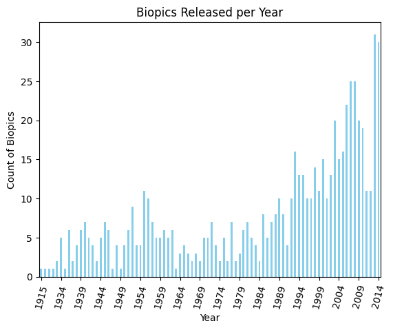

```python
year = df2['year_release']
yearly_count = df2['year_release'].value_counts().sort_index()
print(yearly_count)
yearly_count.plot(kind='bar', color='skyblue')
plt.title('Biopics Released per Year')
plt.xlabel('Year')
plt.ylabel('Count of Biopics')
plt.xticks(range(0, len(yearly_count), 5), rotation=75)
plt.show()
```

#### Query 2: Box Office Success by Year

```
year_release
1915            0.0
1927            0.0
1929            0.0
1930            0.0
1933            0.0
           ...
2010    371881000.0
2011    208828000.0
2012    208310000.0
2013    844836800.0
2014    973378340.0
Name: box_office, Length: 86, dtype: float64
```

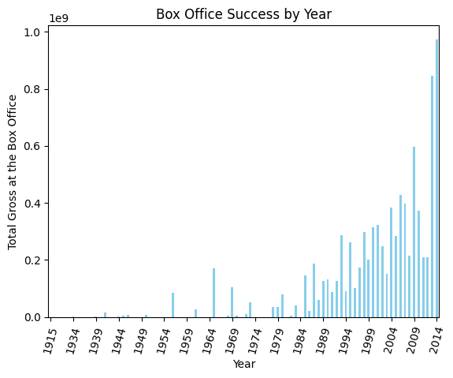

```python
box_success = df2.groupby(year)['box_office'].sum()
print(box_success)
box_success.plot(kind='bar', color='skyblue')
plt.title('Box Office Success by Year')
plt.xlabel('Year')
plt.ylabel('Total Gross at the Box Office')
plt.xticks(range(0, len(box_success), 5), rotation=75)
plt.show()
```

```
year_release
1915    0.000000e+00
1927    0.000000e+00
1929    0.000000e+00
1930    0.000000e+00
1933    0.000000e+00
            ...
2010    1.957268e+07
2011    1.898436e+07
2012    1.893727e+07
2013    2.725280e+07
2014    3.244594e+07
Name: box_office, Length: 86, dtype: float64
```

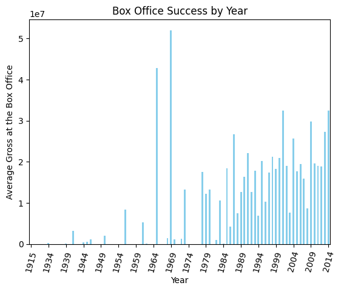

```python
box_mean = df2.groupby(year)['box_office'].mean()
print(box_mean)
box_mean.plot(kind='bar', color='skyblue')
plt.title('Box Office Success by Year')
plt.xlabel('Year')
plt.ylabel('Average Gross at the Box Office')
plt.xticks(range(0, len(box_success), 5), rotation=75)
plt.show()
```

We see from the graph above that the box office follows the same trend as movie releases, with total gross at the box office increasing as more biopics are screened. However, when we look at average gross at the box office, we see a peak in profit in 1969, which is unsuspected. Regardless, the overall increase in profit and production implies that this is a growing genre of movie.